# Will Mick Mulvaney be Replaced as Pres. Trump’s Chief of Staff by 2020-01-01?

This is my analysis for [This Question](https://www.gjopen.com/questions/1100-will-mick-mulvaney-cease-to-be-white-house-chief-of-staff-before-1-january-2020) on [Good Judgement Open](https://www.gjopen.com/).

## Chiefs of Staff

Wikipedia has already assembled [the list of Chiefs of Staff](https://en.wikipedia.org/wiki/White_House_Chief_of_Staff#List_of_White_House_chiefs_of_staff). All we needed to do was compile it into [a slightly cleaner format](https://docs.google.com/spreadsheets/d/e/2PACX-1vRlBabaJaIBmcqvF4QR4uF2megpcCpffX6doQbJaVWq8fMcfmW_iIdqs7iuYvi6LrtJkG5XjXnrybdg/pubhtml?gid=174141588&single=true).

```r
library(readr)
library(dplyr)
library(DT)
CoS <- read_csv('https://docs.google.com/spreadsheets/d/e/2PACX-1vRlBabaJaIBmcqvF4QR4uF2megpcCpffX6doQbJaVWq8fMcfmW_iIdqs7iuYvi6LrtJkG5XjXnrybdg/pub?gid=174141588&single=true&output=csv')
CoS %>%
  select(Name, President, EnteredOffice, LeftOffice, TimeInOffice) %>%
  arrange(desc(EnteredOffice)) %>%
  datatable()
```

|  | Name | President | EnteredOffice | LeftOffice | TimeInOffice |
| --- | --- | --- | --- | --- | --- |
| 1 | Mick Mulvaney | Donald Trump | 2019-01-02 |  |  |
| 2 | John F. Kelly | Donald Trump | 2017-07-31 | 2019-01-02 | 520 |
| 3 | Reince Priebus | Donald Trump | 2017-01-20 | 2017-07-31 | 192 |
| 4 | Denis McDonough | Barack Obama | 2013-01-20 | 2017-01-20 | 1461 |
| 5 | Jack Lew | Barack Obama | 2012-01-27 | 2013-01-20 | 359 |
| 6 | Bill Daley | Barack Obama | 2011-01-13 | 2012-01-27 | 379 |
| 7 | Pete Rouse | Barack Obama | 2010-10-01 | 2011-01-13 | 104 |
| 8 | Rahm Emanuel | Barack Obama | 2009-01-20 | 2010-10-01 | 619 |
| 9 | Joshua Bolten | George W. Bush | 2006-04-14 | 2009-01-20 | 1012 |
| 10 | Andrew Card | George W. Bush | 2001-01-20 | 2006-04-14 | 1910 |

[output cut: 25 more lines]

## Munging

```r
filtered <- CoS %>% filter(Name != "(Vacant)")
```

## Survival

To compute how long a Chief of Staff’s tenure will be, let’s fit a survival curve!

```r
library(survival)
library(survminer)
curve <- survfit(Surv(TimeInOffice) ~ 1, data=CoS)
curve
```

```
## Call: survfit(formula = Surv(TimeInOffice) ~ 1, data = CoS)
##
##    1 observation deleted due to missingness
##       n  events  median 0.95LCL 0.95UCL
##      34      34     581     427     918
```

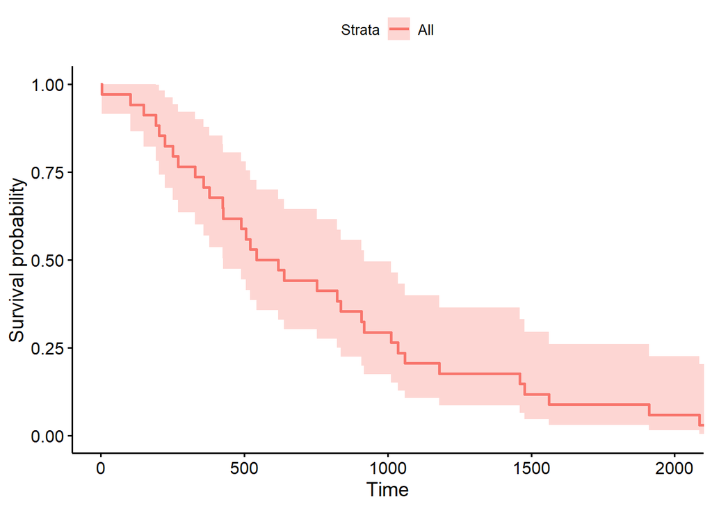

```r
ggsurvplot(curve)
```

Now, since Mulvaney started on 2019-01-02, he’ll need to be in his position 364 days to resolve the question as “No”.

```r
window <- summary(curve, times=364)
window
```

```
## Call: survfit(formula = Surv(TimeInOffice) ~ 1, data = CoS)
##
## 1 observation deleted due to missingness
##  time n.risk n.event survival std.err lower 95% CI upper 95% CI
##   364     24      10    0.706  0.0781        0.568        0.877
```

So, the model suggests that he’ll have a 364-day survival probability of 0.7058824, and thus we predict that he’ll be gone with probability 0.2941176

## …Conditioned on his current longevity

If we condition his survival on the amount of time he’s already made it, our estimate should go up. After all, each additional day constitutes additional Bayesian evidence that he will continue to survive.

```r
#remotes::install_github("zabore/condsurv")
library(condsurv)
csp <- conditional_surv_est(
  basekm = curve,
  t1 = as.integer(difftime(Sys.time(), as.POSIXct('2019-01-02', tz="UTC"), units="days")),
  t2 = 364
)$cs_est
csp
```

```
## [1] 0.92
```

By this perspective, he’s 92% likely to last through the end of the year, or 8% likely to leave.

## Inside View

**(as of 2019-10-25)**

…suggests we shouldn’t be so confident about his longevity:

- 2019-10-22 [Fox News says his job is in jeopardy](https://www.foxnews.com/media/mick-mulvaney-struggles-as-white-house-leaks-say-his-job-is-in-jeopardy)
- 2019-10-23 [President Trump Denies Rumors about replacement plans](https://www.politico.com/news/2019/10/23/trump-replace-chief-of-staff-mulvaney-055585)
- 2019-10-24 [Conservatives express support for Mulvaney](https://www.politico.com/news/2019/10/24/mick-mulvaney-support-conservatives-056618)